# Cyclistic Bike-share Analysis

This is a case study completed as part of the Google Data Analytics Professional Certificate program. The goal here is to analyze the customer data of a bike-share company (Cyclistic) and assess the differences between casual riders (purchasers of single rides or day passes) and Cyclistic members (purchasers of annual memberships). The ultimate goal would be to create a digital media campaign aimed at converting casual riders in Cyclistic members. So let’s get to it!

### Importing libraries and data

The data we’ll be looking at is public bike-share made available by Motivate International Inc. at https://divvy-tripdata.s3.amazonaws.com/index.html, but for our purposes will be used to represent the fictional business Cyclistic. Since the data doesn’t come from a third party source, we’ll operate under the assumption that it’s accurate.

```r
# using the tidyverse collection of libraries to import and look through the most recent month's data
library(tidyverse)
library(ggmap)
trip_data <- read_csv("trip-data/202305-divvy-tripdata.csv")
```

### Processing the data

With the entire data set loaded, let’s see what we have:

```r
head(trip_data)
```

| ride_id | rideable_type | started_at | ended_at | start_station_name | start_station_id | end_station_name | end_station_id | start_lat | start_lng | end_lat | end_lng | member_casual |
| --- | --- | --- | --- | --- | --- | --- | --- | --- | --- | --- | --- | --- |
| 0D9FA920C3062031 | electric_bike | 2023-05-07 19:53:48 | 2023-05-07 19:58:32 | Southport Ave & Belmont Ave | 13229 | NA | NA | 41.93941 | -87.66383 | 41.93000 | -87.65000 | member |
| 92485E5FB5888ACD | electric_bike | 2023-05-06 18:54:08 | 2023-05-06 19:03:35 | Southport Ave & Belmont Ave | 13229 | NA | NA | 41.93948 | -87.66385 | 41.94000 | -87.69000 | member |
| FB144B3FC8300187 | electric_bike | 2023-05-21 00:40:21 | 2023-05-21 00:44:36 | Halsted St & 21st St | 13162 | NA | NA | 41.85379 | -87.64672 | 41.86000 | -87.65000 | member |
| DDEB93BC2CE9AA77 | classic_bike | 2023-05-10 16:47:01 | 2023-05-10 16:59:52 | Carpenter St & Huron St | 13196 | Damen Ave & Cortland St | 13133 | 41.89456 | -87.65345 | 41.91598 | -87.67733 | member |
| C07B70172FC92F59 | classic_bike | 2023-05-09 18:30:34 | 2023-05-09 18:39:28 | Southport Ave & Clark St | TA1308000047 | Southport Ave & Belmont Ave | 13229 | 41.95708 | -87.66420 | 41.93948 | -87.66375 | member |
| 2BA66385DF8F815A | classic_bike | 2023-05-30 15:01:21 | 2023-05-30 15:17:00 | Clinton St & Madison St | TA1305000032 | McClurg Ct & Ohio St | TA1306000029 | 41.88275 | -87.64119 | 41.89259 | -87.61729 | member |

```r
glimpse(trip_data)
```

```
Rows: 604,827
Columns: 13
$ ride_id            <chr> "0D9FA920C3062031", "92485E5FB5888ACD", "~
$ rideable_type      <chr> "electric_bike", "electric_bike", "electr~
$ started_at         <dttm> 2023-05-07 19:53:48, 2023-05-06 18:54:08~
$ ended_at           <dttm> 2023-05-07 19:58:32, 2023-05-06 19:03:35~
$ start_station_name <chr> "Southport Ave & Belmont Ave", "Southport~
$ start_station_id   <chr> "13229", "13229", "13162", "13196", "TA13~
$ end_station_name   <chr> NA, NA, NA, "Damen Ave & Cortland St", "S~
$ end_station_id     <chr> NA, NA, NA, "13133", "13229", "TA13060000~
$ start_lat          <dbl> 41.93941, 41.93948, 41.85379, 41.89456, 4~
$ start_lng          <dbl> -87.66383, -87.66385, -87.64672, -87.6534~
$ end_lat            <dbl> 41.93000, 41.94000, 41.86000, 41.91598, 4~
$ end_lng            <dbl> -87.65000, -87.69000, -87.65000, -87.6773~
$ member_casual      <chr> "member", "member", "member", "member", "~
```

Finding some missing values, how many do we have in each column?

```r
# summing up NA values for every column
sapply(trip_data, function(x) sum(is.na(x)))
```

```
           ride_id      rideable_type         started_at
                 0                  0                  0
          ended_at start_station_name   start_station_id
                 0              89240              89240
  end_station_name     end_station_id          start_lat
             95267              95267                  0
         start_lng            end_lat            end_lng
                 0                710                710
     member_casual
                 0
```

It looks like about 15% of both the start and end stations are missing values. Luckily we’ve also got geographic coordinates for these locations, of which only an insignificant number are missing values, so we can safely purge those entries. We’ll get rid of the station name and id columns, as well as ride_id since this just appears to be a unique id for every entry.

```r
# selecting desired columns and filtering out rows with NA values
trip_data_clean <- trip_data %>%
  select(
    c(!ride_id &
        !start_station_name &
        !start_station_id &
        !end_station_name &
        !end_station_id)
  ) %>%
  filter(c(!is.na(end_lat) & !is.na(end_lng)))
# rechecking NA values
sapply(trip_data_clean, function(x) sum(is.na(x)))
```

```
rideable_type    started_at      ended_at     start_lat     start_lng
            0             0             0             0             0
      end_lat       end_lng member_casual
            0             0             0
```

Perfect. Before moving on let’s see what kind of values we have for rideable_type and member_casual.

```r
distinct(trip_data_clean, rideable_type)
```

| rideable_type |
| --- |
| electric_bike |
| classic_bike |
| docked_bike |

```r
distinct(trip_data_clean, member_casual)
```

| member_casual |
| --- |
| member |
| casual |

Okay, it looks like we have 3 bike types and the 2 expected member levels; now we can infer some data from what we have, such as ride length and day of the week the ride was started.

```r
# adding length of ride as ride_minutes and weekday started as day_of_week
trip_data_rich <- trip_data_clean %>%
  mutate(
    ride_minutes = as.numeric(ended_at - started_at) / 60,
    day_of_week = weekdays(started_at)
  )
# taking a look at the new data set
glimpse(trip_data_rich)
```

```
Rows: 604,117
Columns: 10
$ rideable_type <chr> "electric_bike", "electric_bike", "electric_bi~
$ started_at    <dttm> 2023-05-07 19:53:48, 2023-05-06 18:54:08, 202~
$ ended_at      <dttm> 2023-05-07 19:58:32, 2023-05-06 19:03:35, 202~
$ start_lat     <dbl> 41.93941, 41.93948, 41.85379, 41.89456, 41.957~
$ start_lng     <dbl> -87.66383, -87.66385, -87.64672, -87.65345, -8~
$ end_lat       <dbl> 41.93000, 41.94000, 41.86000, 41.91598, 41.939~
$ end_lng       <dbl> -87.65000, -87.69000, -87.65000, -87.67733, -8~
$ member_casual <chr> "member", "member", "member", "member", "membe~
$ ride_minutes  <dbl> 4.733333, 9.450000, 4.250000, 12.850000, 8.900~
$ day_of_week   <chr> "Sunday", "Saturday", "Sunday", "Wednesday", "~
```

```r
summary(trip_data_rich)
```

```
 rideable_type        started_at
 Length:604117      Min.   :2023-05-01 00:00:33.00
 Class :character   1st Qu.:2023-05-09 21:44:56.00
 Mode  :character   Median :2023-05-18 15:54:41.00
                    Mean   :2023-05-17 18:35:48.41
                    3rd Qu.:2023-05-25 12:37:43.00
                    Max.   :2023-05-31 23:59:58.00
    ended_at                        start_lat       start_lng
 Min.   :2023-05-01 00:04:28.00   Min.   :41.65   Min.   :-87.87
 1st Qu.:2023-05-09 21:57:37.00   1st Qu.:41.88   1st Qu.:-87.66
 Median :2023-05-18 16:10:37.00   Median :41.90   Median :-87.64
 Mean   :2023-05-17 18:52:01.19   Mean   :41.90   Mean   :-87.65
 3rd Qu.:2023-05-25 12:50:20.00   3rd Qu.:41.93   3rd Qu.:-87.63
 Max.   :2023-06-07 23:04:26.00   Max.   :42.07   Max.   :-87.53
    end_lat         end_lng       member_casual
 Min.   :41.62   Min.   :-87.91   Length:604117
 1st Qu.:41.88   1st Qu.:-87.66   Class :character
 Median :41.90   Median :-87.64   Mode  :character
 Mean   :41.90   Mean   :-87.65
 3rd Qu.:41.93   3rd Qu.:-87.63
 Max.   :42.11   Max.   :-87.53
  ride_minutes      day_of_week
 Min.   :   -1.50   Length:604117
 1st Qu.:    5.65   Class :character
 Median :   10.15   Mode  :character
 Mean   :   16.21
 3rd Qu.:   18.25
 Max.   :12136.30
```

Okay it looks like there are some negative ride lengths, so at least some of the ride times weren’t accurately recorded. Given that the lowest duration is less than 2 minutes, it’s most likely just a case of station clocks not being synced to the second, which isn’t too much of a problem for our purposes, but we’ll purge anything with a negative duration.

```r
trip_data_rich <- trip_data_rich %>%
  filter(ride_minutes >= 0)
```

### Analyzing the data

With our data in order, we can start to see how the different member types actually vary. First we’ll see what rideable preferences each member type has.

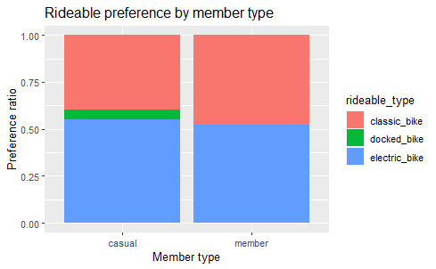

```r
trip_data_rich %>%
  ggplot() +
    geom_bar(aes(member_casual, bg = rideable_type), position = "fill") +
    labs(
      title = "Rideable preference by member type",
      x = "Member type",
      y = "Preference ratio"
  )
```

It appears both groups have very similar bike preferences, with the exception Cyclistic members don’t seem to use docked bikes at all (perhaps this isn’t offered with the annual membership). Let’s see how long both groups rides each rideable.

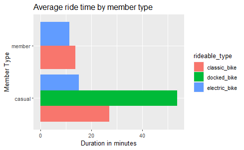

```r
trip_data_rich %>%
  group_by(rideable_type, member_casual) %>%
  reframe(
    ride_minutes = mean(ride_minutes)
  ) %>%
  ggplot() +
    geom_col(aes(ride_minutes, member_casual, bg = rideable_type), position = "dodge") +
    labs(
      title = "Average ride time by member type",
      x = "Duration in minutes",
      y = "Member Type"
    )
```

We can see that casual riders use rideables for longer than Cyclistic members, but also that docked bikes tend to be used for the longest rides. Now to see when they’re riding.

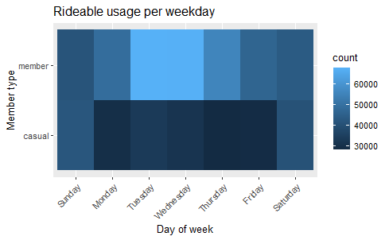

```r
ordered_days <- factor(trip_data_rich$day_of_week, levels = c("Sunday", "Monday", "Tuesday", "Wednesday", "Thursday", "Friday", "Saturday"))
trip_data_rich %>%
  group_by(day_of_week, member_casual) %>%
  ggplot() +
    geom_bin_2d(aes(ordered_days, member_casual)) +
    labs(
      title = "Rideable usage per weekday",
      x = "Day of week",
      y = "Member type"
    ) +
    guides(x = guide_axis(angle = 45))
```

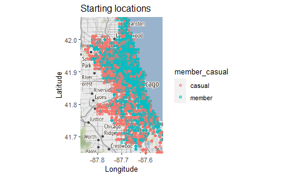

```r
map <- get_stamenmap(
  bbox = c(
    left = min(trip_data_rich$start_lng),
    bottom = min(trip_data_rich$start_lat),
    right = max(trip_data_rich$start_lng),
    top = max(trip_data_rich$start_lat)
  ),
  maptype = "terrain"
)
ggmap(map) + trip_data_rich %>%
  geom_point(mapping = aes(x = start_lng, y = start_lat, color = member_casual), position = "jitter", alpha = .5) +
  labs(
    title = "Starting locations",
    x = "Longitude",
    y = "Latitude"
  )
```

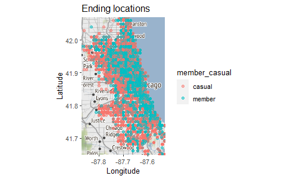

```r
ggmap(map) + trip_data_rich %>%
  geom_point(mapping = aes(x = end_lng, y = end_lat, color = member_casual), position = "jitter", alpha = .5) +
  labs(title = "Ending locations",
    x = "Longitude",
    y = "Latitude"
  )
```

It looks like Cyclistic members tend to be much closer to the downtown area and nearby denser residential areas, while casual riders appear much more in the suburbs.

### Conclusion

The data here shows that the largest differences between member types is weekday usage and which part of the metro area they ride. My suggestion for a next step would be to investigate casual riders’ need or interest in riding on weekdays, and perhaps focusing surveying and campaigning efforts in the suburban outer reaches of the area.